# Introduction : Data Visualisation

Le 05 juin 2018

## Plan du cours

- Manipulation de données (Dplyr)
- Fonction lapply
- Séries temporelles (quantmod et lubridates)

## Dplyr

Le principe de ce paquet est d'utiliser des fonctions de haut niveau de manipulation d'objet de données. La syntaxe et la philosophie de ce paquet est similaire au langage SQL.

Il permet de réduire dans la plupart des cas la taille du code écrit gràce à cet objet `%>%` (un opérateur assimilable au `+` dans ggplot2). A l'instar de Ggplot, il possède une grammaire de manipulation de données. Les verbes (les fonctions) de ce paquet permettent de résoudre des problèmes communs de manipulation de données.

## Dplyr

Nous allons étudier les 5 fonctions de dplyr : `mutate()`, `filter()`, `select()`, `arrange()` et finalement `summarise()`

**Source :**

[Cours de data mining](https://laurentpolitis.github.io/FIN406_2017/docs/data-mining.html)

[Présentation et installation](https://dplyr.tidyverse.org/)

[Introduction](https://cran.r-project.org/web/packages/dplyr/vignettes/dplyr.htmls)

Cours interactif

## Apply function

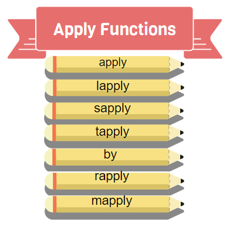

## Exemple d'une application

Le but de cet exemple est de télécharger le taux de l'euros avec d'autre devises et d'arranger les données sous forme de data.frame.

```r
library(tidyquant)
dt = c("EUR/USD", "EUR/JPY", "EUR/GBP") %>%
tq_get(get = "exchange.rates")
df_list = lapply(setNames(object = unique(dt$symbol),
                          nm = unique(dt$symbol)),
                 function(y) return( dt %>%
                   filter(y == symbol)) %>%
                   select(exchange.rate))
#do.call utilsation d'une fonction une liste données
df_data = do.call(what = "cbind",args = df_list)
# changement de noms des colonnes de la data frame
colnames(df_data) = unique(dt$symbol)
rownames(df_data) = (dt %>% filter("EUR/USD"==symbol) %>%
                  select(date))$date
```

## Résulats

```
##             EUR/USD  EUR/JPY  EUR/GBP
## 2017-12-07 1.178983 132.8711 0.879398
## 2017-12-08 1.175806 133.3834 0.874882
## 2017-12-09 1.175806 133.3834 0.874882
## 2017-12-10 1.177126 133.5894 0.879524
## 2017-12-11 1.178530 133.7314 0.881342
## 2017-12-12 1.175814 133.4697 0.881737
```

## Apply

Calcul sur des données avec des structures matricielles :

**Moyenne par colonne**

```r
apply(X =df_data ,MARGIN = 2 ,FUN = mean)
apply(X =df_data ,MARGIN = 2 ,FUN = function(x) {mean(x)})
```

** Moyenne par ligne**

```r
apply(X =df_data ,MARGIN = 1 ,FUN = mean(x))
```

**Les 2**

```r
apply(X =df_data ,MARGIN = c(1,2) ,FUN = mean(x))
```

## Apply : Résultats

Calcul sur des données avec des structures matricielles :

**Moyenne par colonne**

```
##     EUR/USD     EUR/JPY     EUR/GBP
##   1.2130627 132.3232584   0.8805045
```

** Moyenne par ligne**

```
## 2017-12-07 2017-12-08 2017-12-09 2017-12-10 2017-12-11
##   44.97650   45.14468   45.14468   45.21534   45.26375
```

**Les 2**

```
##             EUR/USD  EUR/JPY  EUR/GBP
## 2017-12-07 1.178983 132.8711 0.879398
## 2017-12-08 1.175806 133.3834 0.874882
```

## sapply et lapply

En fonction de la situation, vous pouvez utiliser soit sapply pour un format vectoriel et lapply pour des listes.

```r
head(sapply(df_data$`EUR/USD`, function(x)
  abs((x-mean(df_data$`EUR/USD`))/sd(df_data$`EUR/USD`))))
```

```
## [1] 1.364520 1.491724 1.491724 1.438872 1.382657 1.491404
```

```r
head(lapply(df_data$`EUR/USD`, function(x)
  abs((x-mean(df_data$`EUR/USD`))/sd(df_data$`EUR/USD`))))
```

```
## [[1]]
## [1] 1.36452
##
## [[2]]
## [1] 1.491724
##
## [[3]]
## [1] 1.491724
##
## [[4]]
## [1] 1.438872
##
## [[5]]
## [1] 1.382657
##
## [[6]]
## [1] 1.491404
```

## Parallelisation

Si vous souhaitez augmenter la vitesse de votre code, vous pouvez utiliser le package parallel sur linux.

```r
library(parallel)
n = 1
time = Sys.time()
a = mclapply(df_data$`EUR/USD`, FUN = function(x)
  abs((x-mean(df_data$`EUR/USD`))/sd(df_data$`EUR/USD`)),
  mc.cores =n)

print(paste("Avec Parallelisation",Sys.time()-time))
```

```
## [1] "Avec Parallelisation 0.0210540294647217"
```